# PEC1 Análisis de Datos Ómicos

Francisco Abel Cedrón Santaeufemia

1 de Mayo de 2020

# 1. Identificar que grupos hay y a qué grupo pertenece cada muestra.

Para este estudio se ha seleccionado el estudio GSE130586 El primer paso es descargar los archivos .CEL que se obtienen a partir de los archivos disponibles en GEO (Gene Expression Omnibus).

```
# codigo ejecutado en zsh
curl -O "https://www.ncbi.nlm.nih.gov/geo/download/?acc=GSE130586&format=file"
mv "?acc=GSE130586&format=file" GSE130586_RAW.tar
tar xf GSE130586_RAW.tar
for i in `ls *CEL.gz`; do gunzip $i; done
mkdir -p db
mv *CEL db/
```

Una vez que tenemos los archivos en formato **CEL** nos encontraremos con 8 muestras diferentes, correspondientes a las muestra obtenidas en ratones.

Antes de empezar con el estudio, guardamos manualmente la información relacionada con las muestras en el archivo **targets.csv** que se encuentra en la carpeta **db**.

```r
targets.pec <- read.csv2("db/targets.csv", header=TRUE, sep=";")
knitr::kable(targets.pec, booktabs=TRUE, caption="Información del archivo targets que se ha creado manualmente")
```

Información del archivo targets que se ha creado manualmente

| FileName | Group | Genotype | Treatment | ShortName |
| --- | --- | --- | --- | --- |
| GSM3744179_WT_1.CEL | WT_ntBmdms | WT | Not-treated | wt_nt.1 |
| GSM3744180_WT_2.CEL | WT_ntBmdms | WT | Not-treated | wt_nt.2 |
| GSM3744181_WT_LPS_1.CEL | WT_Bmdms | WT | LPS | wt.1 |
| GSM3744182_WT_LPS_2.CEL | WT_Bmdms | WT | LPS | wt.2 |
| GSM3744183_aKO_1.CEL | aKO_ntBmdms | aKO | Not-treated | ako_nt.1 |
| GSM3744184_aKO_2.CEL | aKO_ntBmdms | aKO | Not-treated | ako_nt.2 |
| GSM3744185_aKO_LPS_1.CEL | aKO_Bmdms | aKO | LPS | ako.1 |
| GSM3744186_aKO_LPS_2.CEL | aKO_Bmdms | aKO | LPS | ako.2 |

Una vez que tenemos los targets cargados, es necesario leer el contenido descargado de GEO, para lo que nos apoyamos en el paquete `oligo` que contiene la función `list.celfiles`. Después, podremos empelar el contenido del archivo `targets.csv` y asociarlo con la información obtenida de la base de datos GEO y para eso utilizaremos el paquete `Biobase` ya que nos proporciona la función `read.AnnotatedDataFrame` para este proposito.

```r
archivosCEL <- list.celfiles("db", full.names=TRUE)
mis.targets <- read.AnnotatedDataFrame("db/targets.csv", header=TRUE, row.names=1, sep=";")
rawData <- read.celfiles(archivosCEL, phenoData=mis.targets)
mis.targets@data$ShortName -> rownames(pData(rawData))
colnames(rawData) <- rownames(pData(rawData))
```

Podemos comprobar que nuestros datos contienen las 8 muestras que nos indicaba la base de datos GEO para el estudio GSE130586.

```r
head(rawData)
```

```
## ExpressionFeatureSet (storageMode: lockedEnvironment)
## assayData: 1 features, 8 samples
##   element names: exprs
## protocolData
##   rowNames: wt_nt.1 wt_nt.2 ... ako.2 (8 total)
##   varLabels: exprs dates
##   varMetadata: labelDescription channel
## phenoData
##   rowNames: wt_nt.1 wt_nt.2 ... ako.2 (8 total)
##   varLabels: Group Genotype Treatment ShortName
##   varMetadata: labelDescription channel
## featureData: none
## experimentData: use 'experimentData(object)'
## Annotation: pd.clariom.s.mouse
```

# 2. Control de calidad de los datos crudos.

Antes de realizar cualquier proceso en los datos es necesario determinar la calidad de los datos.

Para empezar el análisis procedemos a realiar un análisis por componentes principales donde se muestra cada uno de los cuatro grupos del esutio de un color diferente.

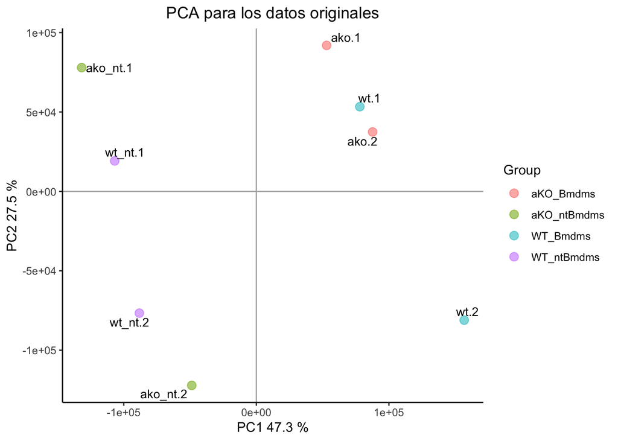

```r
plotPCA3(exprs(rawData), labels=targets.pec$ShortName, factor=targets.pec$Group,
        title="PCA para los datos originales", scale=FALSE, size=3.5)
```

El análisis por componentes principales nos muestra que existe un 47.3% de variabilidad en las muestras.

A continuación se muestran los datos mediante un boxplot y un instograma ya que permiten analizar visualemente la disparidad que hay con los datos originales. El boxplot permite mostrar la districuión y el histograma muestra la semejanza entre la posición y la forma de las muestras del estudio.

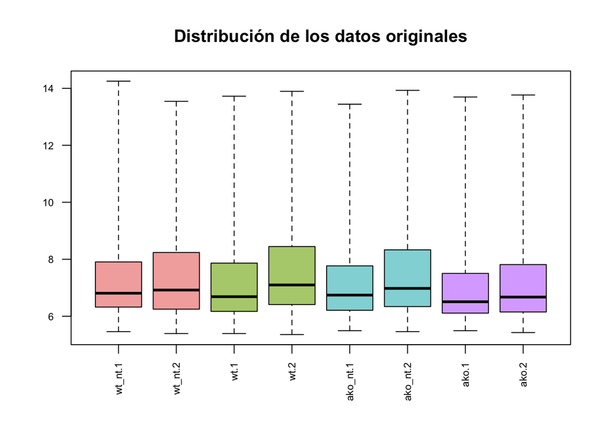

```r
boxplot(rawData, cex.axis=0.7, las=2, which="all", col=c(rep("#f4aeac",2), rep("#b3cf7c",2), rep("#91d7da",2), rep("#dbaeff",2)), main="Distribución de los datos originales")
```

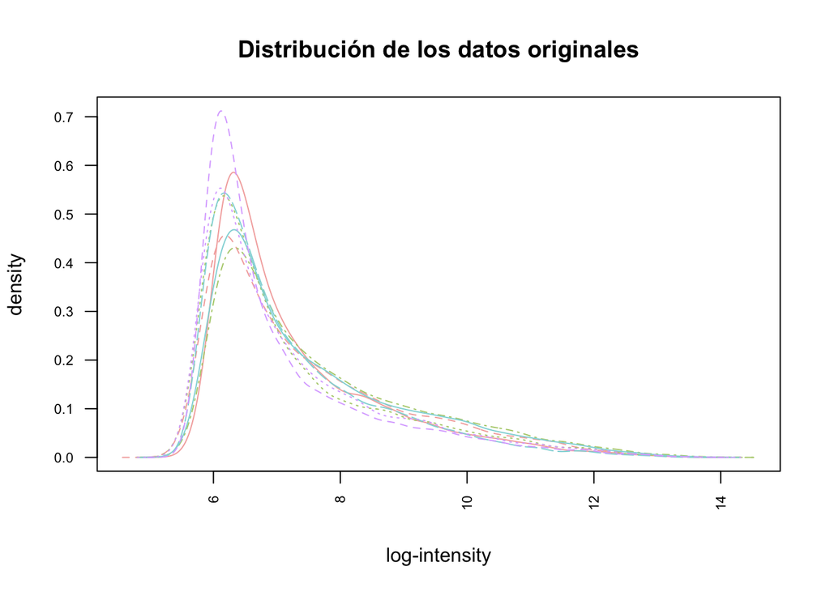

```r
hist(rawData, cex.axis=0.7, las=2, which="all", col=c(rep("#f4aeac",2), rep("#b3cf7c",2), rep("#91d7da",2), rep("#dbaeff",2)), main="Distribución de los datos originales")
```

# 3. Normalización

Para poder realizar esta tarea, la normalización se reaalizará utilizando el método **RMA** (Robust multi-array average) ya que no proporciona las deficiencias de los métodos anteriores (como por ejemplo MAS5 y MAS4).

```r
eset_rma.pec <- rma(rawData)
```

```
## Background correcting
## Normalizing
## Calculating Expression
```

```r
eset_rma.pec
```

```
## ExpressionSet (storageMode: lockedEnvironment)
## assayData: 29129 features, 8 samples
##   element names: exprs
## protocolData
##   rowNames: wt_nt.1 wt_nt.2 ... ako.2 (8 total)
##   varLabels: exprs dates
##   varMetadata: labelDescription channel
## phenoData
##   rowNames: wt_nt.1 wt_nt.2 ... ako.2 (8 total)
##   varLabels: Group Genotype Treatment ShortName
##   varMetadata: labelDescription channel
## featureData: none
## experimentData: use 'experimentData(object)'
## Annotation: pd.clariom.s.mouse
```

```r
class(eset_rma.pec)
```

```
## [1] "ExpressionSet"
## attr(,"package")
## [1] "Biobase"
```

```r
head(exprs(eset_rma.pec),2)
```

```
##                 wt_nt.1  wt_nt.2     wt.1     wt.2 ako_nt.1 ako_nt.2    ako.1
## AFFX-BioB-3_at 9.193552 7.837314 9.295779 8.072747 9.067033 7.910116 9.060127
## AFFX-BioB-5_at 9.626147 8.092605 9.369613 8.217987 9.593666 8.189435 9.444374
##                   ako.2
## AFFX-BioB-3_at 7.998804
## AFFX-BioB-5_at 8.556121
```

# 4. Control de calidad de los datos normalizados

```r
arrayQualityMetrics(eset_rma.pec, outdir="results/QCDir.Norm", force=TRUE)
```

Realizamos también un analisis de componentes principales de los datos normalizados:

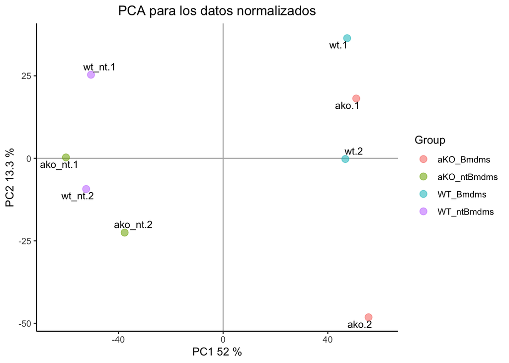

```r
plotPCA3(exprs(eset_rma.pec), labels=targets.pec$ShortName, factor=targets.pec$Group,
        title="PCA para los datos normalizados", scale=FALSE, size=3.5)
```

El PCA nos muestra que ahora la variabilidad está en un 52%.

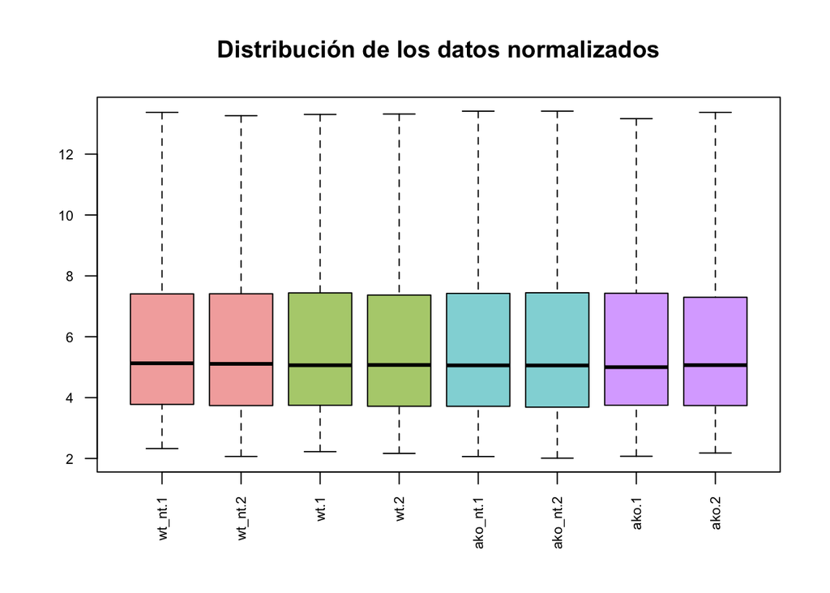

```r
boxplot(eset_rma.pec, cex.axis=0.7, las=2, which="all", col=c(rep("#f4aeac",2), rep("#b3cf7c",2), rep("#91d7da",2), rep("#dbaeff",2)), main="Distribución de los datos normalizados")
```

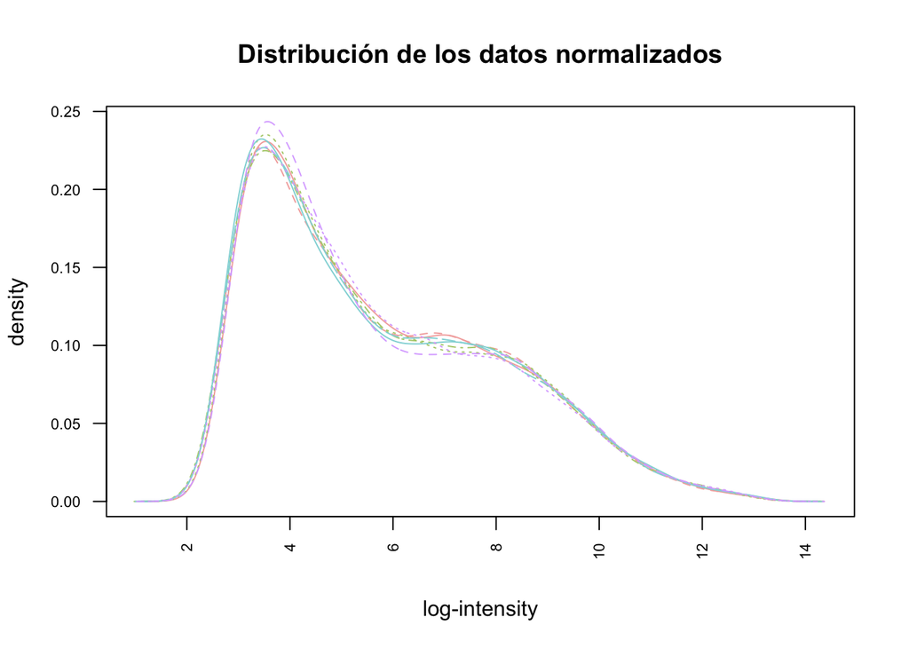

```r
hist(eset_rma.pec, cex.axis=0.7, las=2, col=c(rep("#f4aeac",2), rep("#b3cf7c",2), rep("#91d7da",2), rep("#dbaeff",2)), main="Distribución de los datos normalizados")
```

Aunque los datos originales se encontraban dentro de un rango pequeño se ha logrado que todos estén tentre los mismo valores, lo que permite analizarlos con más seguridad ya que se han eliminados los sesgos que pudieran contener los datos originales. Se puede observar que que con el digrama de cajas la luminiscencia se establece en un mismo grado, mientras que el histogrma indica que se han homogeinizado los datos.

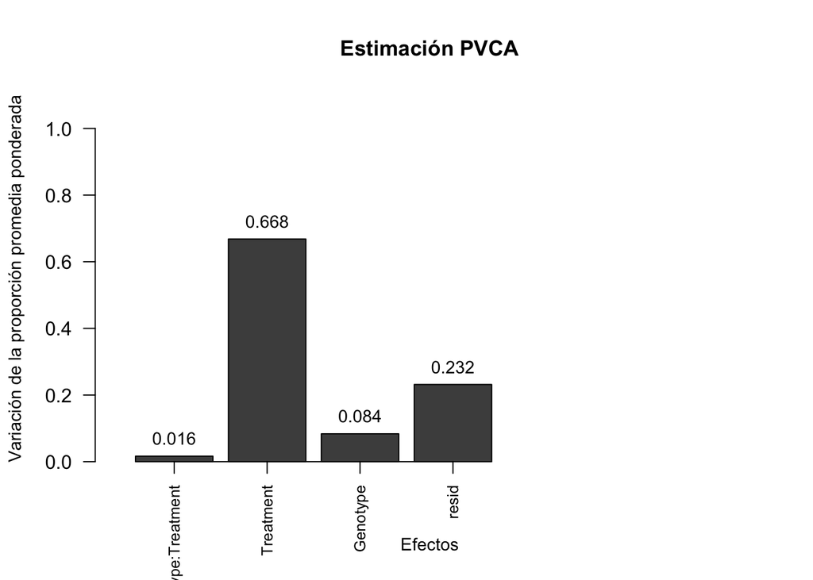

```r
pData(eset_rma.pec) <- targets.pec
pct_threshold <- 0.6
batch.factors <- c("Genotype", "Treatment")
pvcaObj <- pvcaBatchAssess(eset_rma.pec, batch.factors, pct_threshold)

bp <- barplot(pvcaObj$dat, xlab = "Efectos", ylab = "Variación de la proporción promedia ponderada", ylim = c(0,1.1), las=2, main="Estimación PVCA", xlim = c(0,8), cex.main = 1.1, cex.lab = 0.9)
axis(1, at = bp, labels = pvcaObj$label, cex.axis = 0.8, las=2)
values = pvcaObj$dat
new_values = round(values, 3)
text(bp, pvcaObj$dat, labels = new_values, pos =3, cex = 0.9)
```

Este gráfico muestra que la fuente de variación mas alta es la condición del tratamiento, que es algo que se mostraba en los gráficos anteriores.

# 5. Filtraje no específico

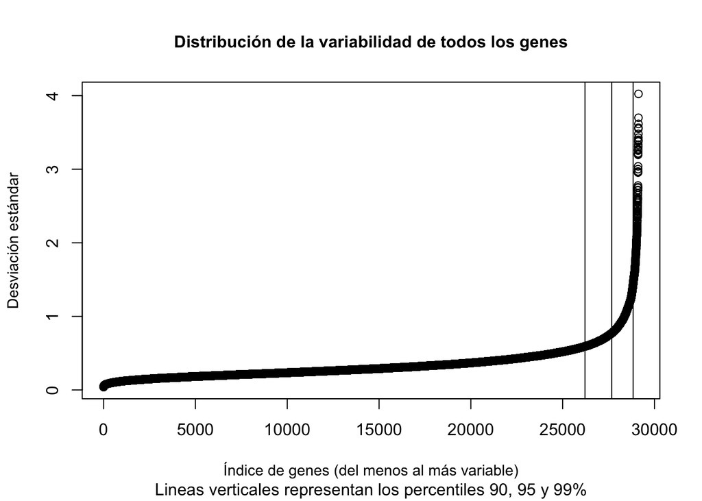

```r
sds <- apply(exprs(eset_rma.pec), 1, sd)
sds0 <- sort(sds)
plot(1:length(sds0), sds0, main="Distribución de la variabilidad de todos los genes", sub="Lineas verticales representan los percentiles 90, 95 y 99%", xlab= "Índice de genes (del menos al más variable)", ylab="Desviación estándar", cex.main = 1, cex.lab = 0.9)
abline(v=length(sds)*c(0.9,0.95, 0.99))
```

El filtrado de los genes menos variables, aquellos que pueden atribuirse a variabilidad aleatoria, que no se consideran diferencialmente expresados, lo que permit eincrementar la potencia.

Para poder eliminar esos genes podemos emplear el paquete **genefilter** ya que nos proporciona la función **nsFilter** que elimina los genes que varían poco entre las condiciones.

```r
annotation(eset_rma.pec) <- "clariomsmousetranscriptcluster.db"
filtered.pec <- nsFilter(eset_rma.pec, require.entrez = TRUE, remove.dupEntrez = TRUE, var.filter = TRUE, var.func = IQR, var.cutoff = 0.5, filterByQuantile = TRUE, feature.exclude = "^AFFX")
print(filtered.pec$filter.log)
```

```
## $numDupsRemoved
## [1] 135
##
## $numLowVar
## [1] 10146
##
## $numRemoved.ENTREZID
## [1] 8703
```

```r
eset_filtered.pec <- filtered.pec$eset
eset_filtered.pec
```

```
## ExpressionSet (storageMode: lockedEnvironment)
## assayData: 10145 features, 8 samples
##   element names: exprs
## protocolData
##   rowNames: wt_nt.1 wt_nt.2 ... ako.2 (8 total)
##   varLabels: exprs dates
##   varMetadata: labelDescription channel
## phenoData
##   rowNames: 1 2 ... 8 (8 total)
##   varLabels: FileName Group ... ShortName (5 total)
##   varMetadata: labelDescription channel
## featureData: none
## experimentData: use 'experimentData(object)'
## Annotation: clariomsmousetranscriptcluster.db
```

Después del filtraje observamos que nos quedamos con 10145 genes y que hemos guardado estos en la variable **eset_filtered.pec**. Guardamos los datos normalizados y filtrados:

```r
write.csv(exprs(eset_rma.pec), file="results/datos.normalizados.csv")
write.csv(exprs(eset_filtered.pec), file="results/datos.normalizados.filtrados.csv")
save(eset_rma.pec, eset_filtered.pec, file="results/datos.normalizados.Rda")
```

# 6. Identificación de genes diferencialmente expresados

## 6.1 Matriz de diseño

En este punto vamos a proceder a crear la matriz de diseño para escoger los genes diferencialmente expresados para comparar la expresión génica entre los grupos. Gracias al paquete **limma** poderemos usar el modelo **Smyth**

```r
library(limma)
Matdesign <- model.matrix(~0+Group, pData(eset_filtered.pec))
colnames(Matdesign) <- c("WT_ntBmdms", "WT_Bmdms", "aKO_ntBmdms", "aKO_Bmdms")
print(Matdesign)
```

```
##   WT_ntBmdms WT_Bmdms aKO_ntBmdms aKO_Bmdms
## 1          0        0           0         1
## 2          0        0           0         1
## 3          0        0           1         0
## 4          0        0           1         0
## 5          0        1           0         0
## 6          0        1           0         0
## 7          1        0           0         0
## 8          1        0           0         0
## attr(,"assign")
## [1] 1 1 1 1
## attr(,"contrasts")
## attr(,"contrasts")$Group
## [1] "contr.treatment"
```

## 6.2 Matriz de contrastes

La pregunta del estudio es la diferenciación celular de los macrófagos derivados de la médula ósea (BMDM).

```r
Matcontrast <- makeContrasts(nt.WTvsAKO=aKO_ntBmdms-WT_ntBmdms, WT.ntvsBMDMS=WT_Bmdms-WT_ntBmdms, AKO.ntvsBMDMS=aKO_Bmdms-aKO_ntBmdms, levels = Matdesign)
print(Matcontrast)
```

```
##              Contrasts
## Levels        nt.WTvsAKO WT.ntvsBMDMS AKO.ntvsBMDMS
##   WT_ntBmdms          -1           -1             0
##   WT_Bmdms             0            1             0
##   aKO_ntBmdms          1            0            -1
##   aKO_Bmdms            0            0             1
```

## 6.3 Estimación del modelo y selección de genes

En este punto podemos proceder a estimar el modelo y los contrastes para así generar los test de significancia para determinar si los genes están diferencialmente expresados. Para ello utilizaremos el paquete **limma** porque incluye modelos de Bayes (como los folds) y nos permite ajunstar los p-valores usando el método de Benjamini y Hochberg.

```r
fit.pec <- lmFit(eset_filtered.pec, Matdesign)
fit.main.pec <- contrasts.fit(fit.pec, Matcontrast)
fit.main.pec <- eBayes(fit.main.pec)
class(fit.main.pec)
```

```
## [1] "MArrayLM"
## attr(,"package")
## [1] "limma"
```

Ahora podemos usar la función **topTable** para asi obtener la lista ordenada por el p-valor de los genes diferencialmente expresados.

```r
tt_nt.WTvsAKO <- topTable(fit.main.pec, number=nrow(fit.main.pec), coef = "nt.WTvsAKO", adjust = "fdr")
head(tt_nt.WTvsAKO)
```

```
##                      logFC  AveExpr         t      P.Value   adj.P.Val        B
## TC0200004109.mm.2 3.607756 7.613278 13.170765 1.225215e-08 0.000124298 7.613454
## TC0500000922.mm.2 3.793908 4.583795 10.640433 1.399393e-07 0.000709842 6.255982
## TC0200001765.mm.2 2.662183 5.196232  8.478123 1.687337e-06 0.005706013 4.615675
## TC1000001189.mm.2 3.173419 5.506671  7.682912 4.753776e-06 0.012056764 3.864239
## TC1800000980.mm.2 1.977563 4.912783  7.079865 1.096224e-05 0.018545517 3.231452
## TC0500000283.mm.2 2.193033 5.303496  7.079479 1.096827e-05 0.018545517 3.231027
```

```r
library(xlsx)
write.xlsx(tt_nt.WTvsAKO, file = "results/tt_nt.WTvsAKO.xlsx")
```

```r
tt_WT.ntvsBMDMS <- topTable(fit.main.pec, number=nrow(fit.main.pec), coef = "WT.ntvsBMDMS", adjust = "fdr")
head(tt_WT.ntvsBMDMS)
```

```
##                       logFC   AveExpr         t      P.Value    adj.P.Val
## TC1100001171.mm.2 -7.533628  8.254696 -25.97888 3.718179e-12 3.772093e-08
## TC0500002755.mm.2 -6.969646  7.119319 -23.30093 1.390294e-11 6.938853e-08
## TC1100003396.mm.2 -6.491392  9.950260 -22.56264 2.051903e-11 6.938853e-08
## TC0200003303.mm.2 -6.688593 10.186613 -20.61259 6.101322e-11 1.257221e-07
## TC0500000468.mm.2 -6.405187  7.923470 -20.58615 6.196258e-11 1.257221e-07
## TC0800002905.mm.2 -6.899690  7.645526 -19.86750 9.496441e-11 1.605690e-07
##                          B
## TC1100001171.mm.2 17.37198
## TC0500002755.mm.2 16.36342
## TC1100003396.mm.2 16.05413
## TC0200003303.mm.2 15.16206
## TC0500000468.mm.2 15.14916
## TC0800002905.mm.2 14.78948
```

```r
write.xlsx(tt_WT.ntvsBMDMS, file = "results/tt_WT.ntvsBMDMS.xlsx")
```

```r
tt_AKO.ntvsBMDMS <- topTable(fit.main.pec, number=nrow(fit.main.pec), coef="AKO.ntvsBMDMS", adjust = "fdr")
head(tt_AKO.ntvsBMDMS)
```

```
##                       logFC  AveExpr         t      P.Value    adj.P.Val
## TC1100001171.mm.2 -7.509071 8.254696 -25.89420 3.868593e-12 3.924688e-08
## TC1100003396.mm.2 -6.516501 9.950260 -22.64992 1.958391e-11 7.736431e-08
## TC0100001338.mm.2 -6.595845 7.655990 -22.34747 2.303676e-11 7.736431e-08
## TC0500002755.mm.2 -6.530759 7.119319 -21.83364 3.050342e-11 7.736431e-08
## TC0700002128.mm.2 -5.534620 9.579474 -20.35973 7.077522e-11 1.133290e-07
## TC0200003278.mm.2 -7.014257 8.668475 -20.32705 7.215529e-11 1.133290e-07
##                          B
## TC1100001171.mm.2 17.48862
## TC1100003396.mm.2 16.20281
## TC0100001338.mm.2 16.06930
## TC0500002755.mm.2 15.83653
## TC0700002128.mm.2 15.12459
## TC0200003278.mm.2 15.10801
```

```r
write.xlsx(tt_AKO.ntvsBMDMS, file = "results/tt_AKO.ntvsBMDMS.xlsx")
```

# 7. Anotación de los resultados

La siguiente función nos va a permitir mapear los identificadores que se han usado anteriormente con nombres más adecuados.

```r
annotatedTopTable <- function(topTab, anotPackage) {
 topTab <- cbind(PROBEID=rownames(topTab), topTab)
 myProbes <- rownames(topTab)
 thePackage <- eval(parse(text=anotPackage))
 geneAnots <- select(thePackage, myProbes, c("SYMBOL", "ENTREZID", "GENENAME"))
 annotatedTopTab<- merge(x=geneAnots, y=topTab, by.x="PROBEID", by.y="PROBEID")
return(annotatedTopTab)
}
```

```r
topAnotados_nt.WTvsAKO <- annotatedTopTable(tt_nt.WTvsAKO, anotPackage="clariomsmousetranscriptcluster.db")
topAnotados_WT.ntvsBMDMS <- annotatedTopTable(tt_WT.ntvsBMDMS, anotPackage="clariomsmousetranscriptcluster.db")
topAnotados_AKO.ntvsBMDMS <- annotatedTopTable(tt_AKO.ntvsBMDMS, anotPackage="clariomsmousetranscriptcluster.db")
write.csv(topAnotados_nt.WTvsAKO, file="results/topAnotados_nt.WTvsAKO.csv")
write.csv(topAnotados_WT.ntvsBMDMS, file="results/topAnotados_WT.ntvsBMDMS.csv")
write.csv(topAnotados_AKO.ntvsBMDMS, file="results/topAnotados_AKO.ntvsBMDMS.csv")
```

# 8. Comparación entre distintas comparaciones

```r
res.pec <- decideTests(fit.main.pec, method ="separate", adjust.method = "fdr", p.value = 0.1, lfc = 1)
```

## 8.1 Tabla de anotaciones

```r
sum.res.rows.pec <- apply(abs(res.pec),1,sum)
res.selected.pec <- res.pec[sum.res.rows.pec!=0,]
print(summary(res.pec))
```

```
##        nt.WTvsAKO WT.ntvsBMDMS AKO.ntvsBMDMS
## Down            2          742           749
## NotSig      10132         8498          8637
## Up             11          905           759
```

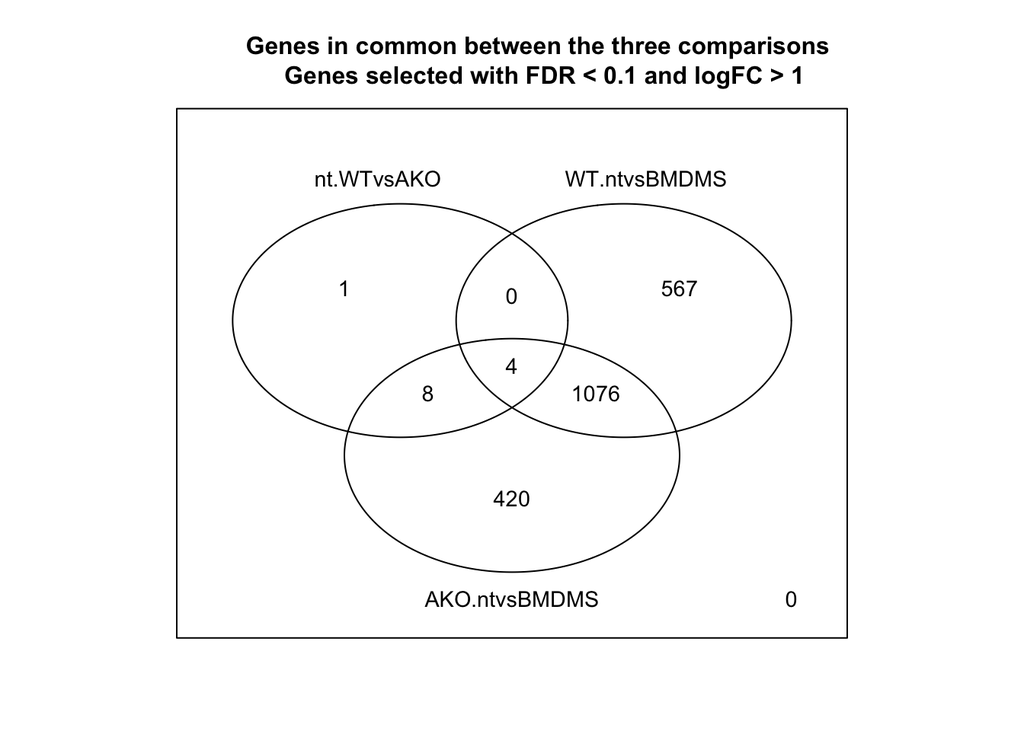

```r
vennDiagram(res.selected.pec[,1:3], cex = 0.9)
title("Genes in common between the three comparisons \n Genes selected with FDR < 0.1 and logFC > 1", cex.main = 1)
```

## 8.2 Visualización de los datos

### 8.2.1 Volcano plots

```r
library(clariomsmousetranscriptcluster.db)
geneSymbols <- select(clariomsmousetranscriptcluster.db, rownames(fit.main.pec), c("SYMBOL"))
```

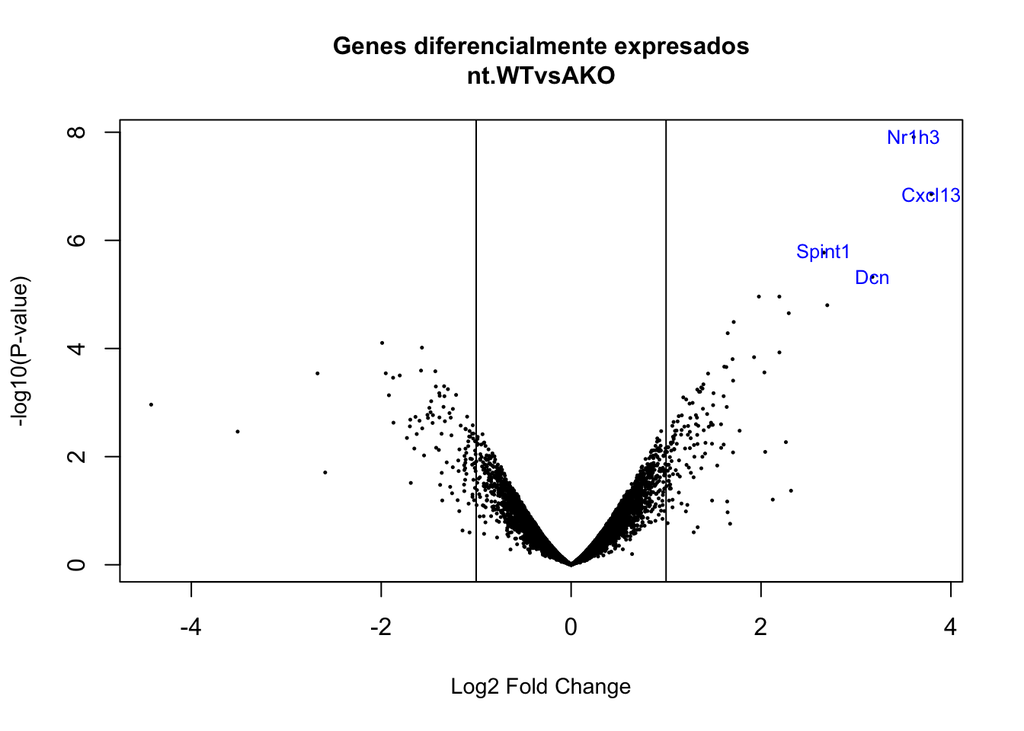

```r
SYMBOLS <- geneSymbols$SYMBOL
volcanoplot(fit.main.pec, coef=1, highlight=4, names=SYMBOLS, main=paste("Genes diferencialmente expresados", colnames(Matcontrast)[1], sep="\n"), cex.main = 1, cex.lab = 0.9)
abline(v=c(-1,1))
```

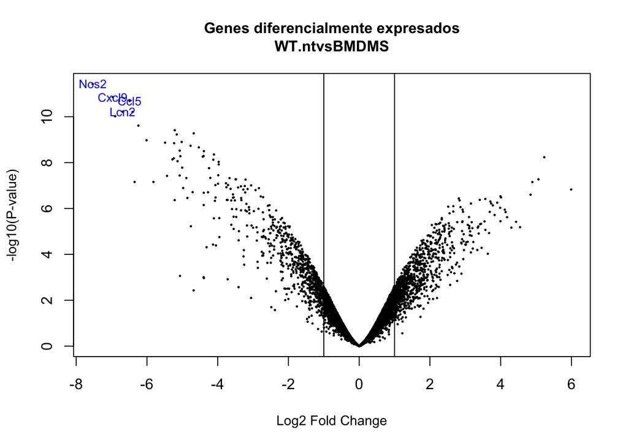

```r
volcanoplot(fit.main.pec, coef=2, highlight=4, names=SYMBOLS, main=paste("Genes diferencialmente expresados", colnames(Matcontrast)[2], sep="\n"), cex.main = 1, cex.lab = 0.9)
abline(v=c(-1,1))
```

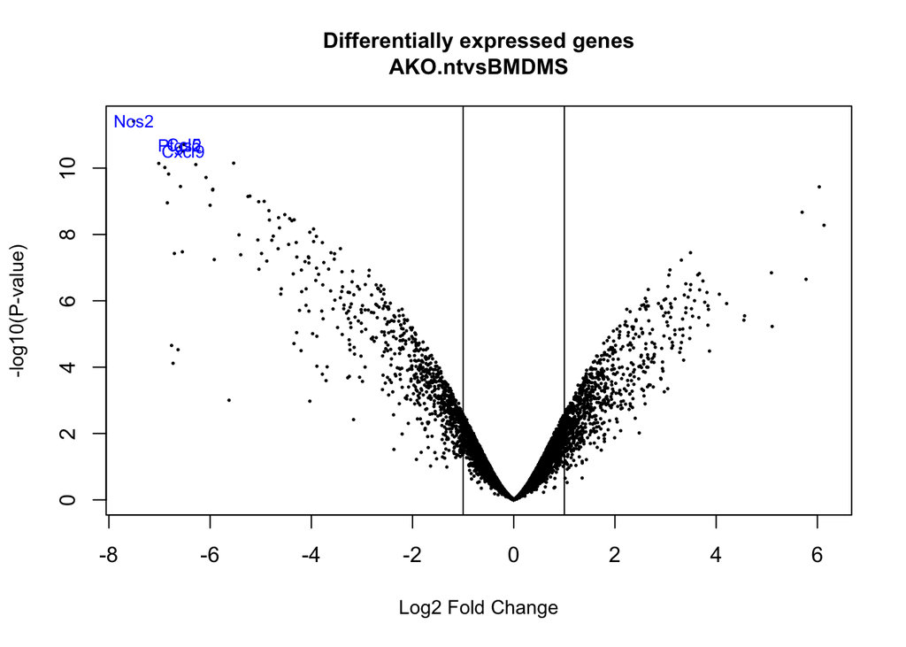

```r
volcanoplot(fit.main.pec, coef=3, highlight=4, names=SYMBOLS, main=paste("Differentially expressed genes", colnames(Matcontrast)[3], sep="\n"), cex.main = 1, cex.lab = 0.9)
abline(v=c(-1,1))
```

### 8.2.2 Heatmaps

```r
probesInHeatmap.pec <- rownames(res.selected.pec)
DatosHM <- exprs(eset_filtered.pec)[rownames(exprs(eset_filtered.pec)) %in% probesInHeatmap.pec,]

geneSymbols <- select(clariomsmousetranscriptcluster.db, rownames(DatosHM), c("SYMBOL"))
SYMBOLS<- geneSymbols$SYMBOL
rownames(DatosHM) <- SYMBOLS
write.csv(DatosHM, file = file.path("results/DatosHM.csv"))
```

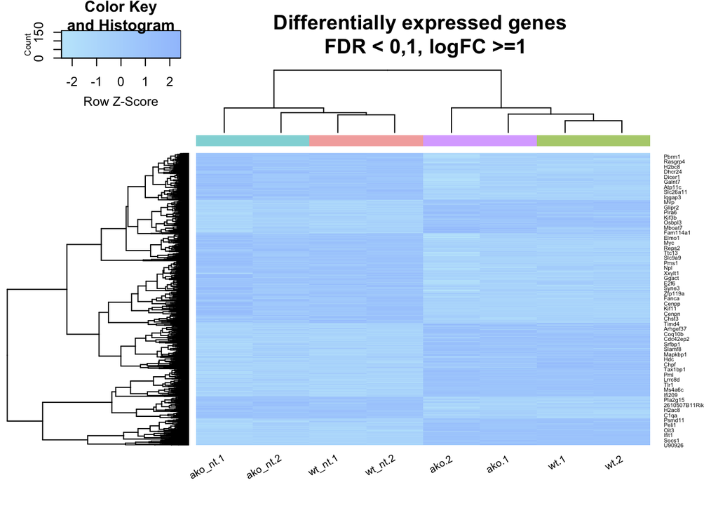

```r
my_palette <- colorRampPalette(c("#c2e9fb", "#a1c4fd"))(n = 299)
heatmap.2(DatosHM, Rowv=TRUE, Colv=TRUE, dendrogram="both", main="Differentially expressed genes \n FDR < 0,1, logFC >=1",
          cex.main=0.8, scale="row", col=my_palette, sepcolor="white", sepwidth=c(0.05,0.05), cexRow=0.5, cexCol=0.9,
          key=TRUE, keysize=1.5, density.info="histogram", tracecol=NULL, srtCol=30,
          ColSideColors=c(rep("#f4aeac",2), rep("#b3cf7c",2), rep("#91d7da",2), rep("#dbaeff",2))
         )
```

# 9. Análisis de significación biológica (“Gene enrichment analysis”)

```r
ListaTablas.pec <- list(nt.WTvsAKO=tt_nt.WTvsAKO, WT.ntvsBMDMS=tt_WT.ntvsBMDMS, AKO.ntvsBMDMS=tt_AKO.ntvsBMDMS)
ListaSeleccionados.pec <- list()
for (i in 1:length(ListaTablas.pec)){
 # select the toptable
 topTab <- ListaTablas.pec[[i]]
 # select the genes to be included in the analysis
 whichGenes<-topTab["adj.P.Val"]<0.15
 selectedIDs <- rownames(topTab)[whichGenes]
 # convert the ID to Entrez
 EntrezIDs<- select(clariomsmousetranscriptcluster.db, selectedIDs, c("ENTREZID"))
 EntrezIDs <- EntrezIDs$ENTREZID
 ListaSeleccionados.pec[[i]] <- EntrezIDs
 names(ListaSeleccionados.pec)[i] <- names(ListaTablas.pec)[i]
}
```

```r
sapply(ListaSeleccionados.pec, length)
```

```
##    nt.WTvsAKO  WT.ntvsBMDMS AKO.ntvsBMDMS
##            25          2917          2480
```

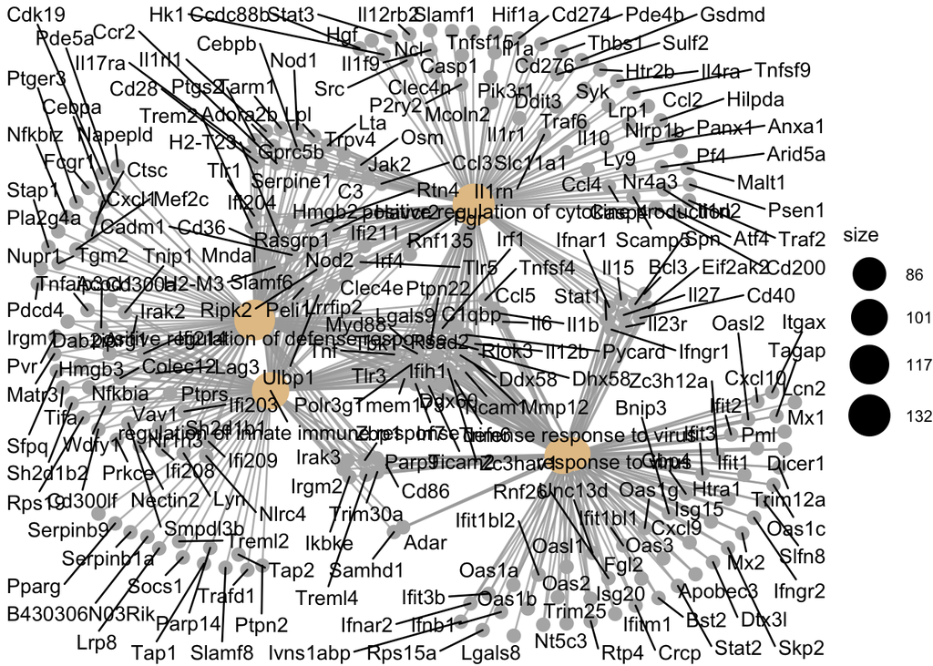

```r
ListaDatos.pec <- ListaSeleccionados.pec[1:3]
comparisonsNames <- names(ListaDatos.pec)

for (i in 1:length(ListaDatos.pec)){
 genesIn <- ListaDatos.pec[[i]]
 comparison <- comparisonsNames[i]
 enrich.result <- enrichGO(gene=genesIn, OrgDb="org.Mm.eg.db", ont="ALL", pAdjustMethod="BH", pvalueCutoff=0.05, readable = TRUE)

 # cat("----------------------------------\nComparison: ", comparison,"\n")
 # print(head(enrich.result))

 if (length(rownames(enrich.result@result)) != 0) {
    write.csv(as.data.frame(enrich.result),  file=paste0("results/","Enrich.Results.",comparison,".csv"), row.names=FALSE)
    write.xlsx(as.data.frame(enrich.result), file=paste0("results/","Enrich.Results.",comparison,".xlsx"), row.names=FALSE)

    pdf(file=paste0("results/","Enrich.Barplot.",comparison,".pdf"))
    print(barplot(enrich.result, showCategory=15, font.size=6, title=paste0("EnrichGO Pathway Analysis for ", comparison,". Barplot")))
    dev.off()

    pdf(file = paste0("results/","EnrichGOcnetplot.",comparison,".pdf"))
    print(cnetplot(enrich.result, categorySize="geneNum", schowCategory=15, vertex.label.cex=0.75))
    dev.off()
 }
}

cnetplot(enrich.result, categorySize="geneNum", schowCategory=15, vertex.label.cex=0.75)
```